# Exploratory Data Analysis | Canadian Cheeses

### Preface

This notebook is written by Kyounggu Yeo. It is meant to be my final project in the Introduction to Machine Learning at the University of British Columbia, which is an exploratory data analysis for the Canadian Cheeses dataset.

# Introduction

We have been asked to create a system that answers the question of whether a cheese contains higher fat or lower fat. This question answering system that we build is called a model, and this model is via a process called training. In machine learning, the goal of training is to create an accurate model that answers our questions correctly most of the time. But in order to train the model, we need to collect data to train on. This is where we will begin.

Our data will be collected from the Canadian Cheeses dataset. There are many aspects of cheeses that we could collect data on - everything from the flavour of cheese to the shape of the cheese. But for our purposes, we’ll just pick two simple ones - the type of milk used and moisture content as a percentage. The hope is that we can split our two types of fat levels along these two factors alone. We’ll call these our features from now on - milk type and moisture. For our exploratory data analysis, we have provided data from the following resources.

### Dataset description

The original data can be found on the [Government of Canada's Open Government Portal](https://open.canada.ca/en) > [Open Data](https://open.canada.ca/en/open-data) > [Agriculture](https://search.open.canada.ca/en/od/?od-search-subjects=Agriculture&_ga=2.936695.774668073.1646111134-817596509.1646111134).

UBC Data Science faculty has done of wrangling and cleaning for the origianl dataset, and provided with a modified version of the dataset.

The `cheese_data` dataset is a table composed of 13 columns, `cheeseId`, `ManufacturerProvCode`, `ManufacturingTypeEn`, `MoisturePercent`, `FlavorEn`, `CharacteristicsEn`, `Organic`, `CategoryTypeEn`, `MilkTypeEn`, `MilkTreatmentTypeEn`, `RindTypeEn`, `CheeseName`, `FatLevel`, stored in a `.csv` file.

The columns are:

- **CheeseId** : The unique Identification number for cheese.
- **ManufacturerProvCode** : The name of province produced the cheese.
- **ManufacturingTypeEn** : The type of manufacturing pocessed the cheese.
- **MoisturePercent** : The percentage of moisture contained in the cheese.
- **FlavorEn** : The flavor of the cheese.
- **CharacteristicsEn** : The chracteristic of the cheese.
- **Organic** : If the cheese is organic or not.(1 = Organic, 0 = Non-organic)
- **CategoryTypeEn** : The type of cheese in category.
- **MilkTypeEn** : The type of milk used for the cheese.
- **MilkTreatmentTypeEn** : The type of treatment the cheese had.
- **RindTypeEn** : The type of rind of the cheese.
- **CheeseName** : The name of the cheese.
- **FatLevel** : The fat level of the cheese.

In our prediction model, we will be using only three columns, `Moisturepercent`, `MilkTypeEn`, and `FatLevel`.

# Exploratory Data Analysis

```python
# Importing all the required libraries needed for my Canadian cheeses anlaysis.
import pandas as pd
import altair as alt
import numpy as np

from sklearn import tree
from sklearn.model_selection import train_test_split, cross_validate
from sklearn.dummy import DummyClassifier
from sklearn.neighbors import KNeighborsClassifier
from sklearn.tree import DecisionTreeClassifier
from sklearn.ensemble import RandomForestClassifier
from sklearn.svm import SVC, SVR
from sklearn.linear_model import LogisticRegression
from sklearn.model_selection import GridSearchCV, RandomizedSearchCV
from sklearn.preprocessing import (FunctionTransformer, Normalizer, OneHotEncoder, StandardScaler, normalize, scale)
from sklearn.compose import ColumnTransformer, make_column_transformer
from sklearn.pipeline import Pipeline, make_pipeline
from sklearn.impute import SimpleImputer
from sklearn.feature_extraction.text import CountVectorizer
from sklearn.metrics import plot_confusion_matrix
from sklearn.metrics import confusion_matrix
from sklearn.metrics import accuracy_score, precision_score, recall_score, f1_score
from sklearn.metrics import classification_report
from sklearn.metrics import make_scorer
from scipy.stats import lognorm, loguniform, randint


# Importing all the required file.
cheese = pd.read_csv("cheese_data.csv")
```

Once we got it all set up, it’s time for our first real step of machine learning - gathering that data. This step is very important because the quality and quantity of data that we gather will directly determine how good our predictive model can be. In this case, the data we collect will be the milk type and moisture content of each cheese. This will yield us a table of milk type, moisture content, and whether it’s a cheese with higher fat or lower fat. This will be our training data.

```python
# Gathering data from the dataset.
cheese_df = cheese.drop(columns=['CheeseId', 'Organic', 'ManufacturerProvCode', 'ManufacturingTypeEn', 'FlavourEn', 'CharacteristicsEn', 'CategoryTypeEn', 'MilkTreatmentTypeEn', 'RindTypeEn', 'CheeseName']).dropna()
cheese_df.head()
```

|  | MoisturePercent | MilkTypeEn | FatLevel |
| --- | --- | --- | --- |
| 0 | 47.0 | Ewe | lower fat |
| 1 | 47.9 | Cow | lower fat |
| 2 | 54.0 | Cow | lower fat |
| 3 | 47.0 | Cow | lower fat |
| 4 | 49.4 | Cow | lower fat |

```python
# The shape of the data.
cheese_df.shape
```

```
(1027, 3)
```

And now it’s time for our next step of machine learning - data preparation - where we load our data into a suitable place and prepare it for use in our machine learning training. We’ll first put all our data together then randomize the ordering. We also need to split the data into two parts. The first part, `Train set`, used in training our model will be the majority of our dataset. The second part, `Test set`, will be used for evaluating our train model’s perfomance.

```python
# Creating X(Feature vectors) and y(Target).
X = cheese_df.drop(columns=["FatLevel"])
y = cheese_df["FatLevel"]

# Data splitting into two parts.
X_train, X_test, y_train, y_test = train_test_split(X, y, test_size=0.3, random_state=123)

X_train.head()
```

|  | MoisturePercent | MilkTypeEn |
| --- | --- | --- |
| 687 | 54.0 | Cow |
| 885 | 55.0 | Goat |
| 861 | 46.0 | Cow |
| 967 | 39.0 | Cow |
| 940 | 42.0 | Goat |

```python
X_train.shape
```

```
(718, 2)
```

Let's see if there are any interesting observations in `X_train`.

```python
# Summary statistics for the dataframe.
X_train.describe()
```

|  | MoisturePercent |
| --- | --- |
| count | 718.000000 |
| mean | 47.083705 |
| std | 9.785916 |
| min | 20.000000 |
| 25% | 40.000000 |
| 50% | 46.000000 |
| 75% | 52.000000 |
| max | 92.000000 |

```python
# Information about the dataframe.
X_train.info()
```

```
<class 'pandas.core.frame.DataFrame'>
Int64Index: 718 entries, 687 to 111
Data columns (total 2 columns):
 #   Column           Non-Null Count  Dtype
---  ------           --------------  -----
 0   MoisturePercent  718 non-null    float64
 1   MilkTypeEn       718 non-null    object
dtypes: float64(1), object(1)
memory usage: 16.8+ KB
```

This is also a good time to do any pertinent visualizations of our data, helping you see if there is any relevant relationships between different variables as well as show you if there are any data imbalances.

```python
# Data visualization.
cheese_plot1 = alt.Chart(cheese_df, width=500, height=300).mark_point().encode(
    x='MoisturePercent',
    y='FatLevel',
    color='FatLevel',
    tooltip=['FatLevel']
).interactive().properties(title='The relationship between moisture and fat level')
cheese_plot1
```

[interactive chart not shown]

```python
# Supporting visualization.
cheese_plot2 = alt.Chart(cheese_df, width=500, height=300).mark_point().encode(
    x='MilkTypeEn',
    y='FatLevel',
    color='FatLevel',
    tooltip=['FatLevel']
).interactive().properties(title='The relationship between milk type and fat level')
cheese_plot2
```

[interactive chart not shown]

# Methode & Results

The next step in our workflow is choosing a model. There are many models that researchers and data scientists have created over the years. In our case, we have just two features - milk type and moisture percentage. Since our predicted(target) value is a categorical value, whether `higher fat` or `lower fat` - we can use a classification model to predict our target.

```python
# Reference: Assignment 6

# Identifying the numeric, categorical, and binary columns.
numeric_feats = ["MoisturePercent"]
categorical_feats = ["MilkTypeEn"]

# 'StandardScaler' removes the mean and scales each feature to unit variance.
numeric_transformer = make_pipeline(SimpleImputer(strategy='median'),
                                    StandardScaler()
                                   )

# 'OneHotEncoder' encodes categorical features as a one-hot numeric array.
categorical_transformer = make_pipeline(SimpleImputer(strategy='most_frequent', fill_value='missing'),
                                        OneHotEncoder(handle_unknown="ignore")
                                   )

# Define a column transformer for the numeric and categorical feature types.
preprocessor = make_column_transformer(
                (numeric_transformer, numeric_feats),
                (categorical_transformer, categorical_feats),
                remainder="passthrough")
```

### Dummy Classifier

This classifier serves as a simple baseline to compare against other more complex classifiers.

```python
# Creating the beseline model.
dummy_clf = DummyClassifier(strategy="prior")

dummy_scores = pd.DataFrame(cross_validate(dummy_clf, X_train, y_train, cv=5, return_train_score=True))
dummy_scores
```

|  | fit_time | score_time | test_score | train_score |
| --- | --- | --- | --- | --- |
| 0 | 0.001317 | 0.000667 | 0.652778 | 0.651568 |
| 1 | 0.001237 | 0.000573 | 0.652778 | 0.651568 |
| 2 | 0.001076 | 0.000572 | 0.652778 | 0.651568 |
| 3 | 0.001072 | 0.000577 | 0.650350 | 0.652174 |
| 4 | 0.001234 | 0.000545 | 0.650350 | 0.652174 |

```python
mean_dummy_training_score = dummy_scores['train_score'].mean()
mean_dummy_cv_score = dummy_scores['test_score'].mean()

mean_dummy_scores = pd.DataFrame({'Mean': ['training_score', 'cv_score'],
                                 'Scores': [mean_dummy_training_score, mean_dummy_cv_score]}
                                 )
mean_dummy_scores
```

|  | Mean | Scores |
| --- | --- | --- |
| 0 | training_score | 0.651810 |
| 1 | cv_score | 0.651807 |

### Random Forest Classifier

This classifier allows quick identification of significant information from vast datasets. The biggest advantage of the Random Forest Classifier is that it relies on collecting various decision trees to arrive at any solution. It performs better accuracy than other classification algorithms.

```python
main_pipe = make_pipeline(preprocessor, RandomForestClassifier(random_state=77, class_weight='balanced'))

scores_df = pd.DataFrame(cross_validate(main_pipe, X_train, y_train, cv=5, return_train_score=True))
scores_df
```

|  | fit_time | score_time | test_score | train_score |
| --- | --- | --- | --- | --- |
| 0 | 0.251276 | 0.020570 | 0.833333 | 0.862369 |
| 1 | 0.209323 | 0.022055 | 0.805556 | 0.865854 |
| 2 | 0.203934 | 0.020509 | 0.833333 | 0.871080 |
| 3 | 0.203330 | 0.020391 | 0.811189 | 0.866087 |
| 4 | 0.201195 | 0.020580 | 0.783217 | 0.871304 |

```python
mean_rfc_training_score = scores_df['train_score'].mean()
mean_rfc_cv_score = scores_df['test_score'].mean()

mean_rfc_scores = pd.DataFrame({'Mean': ['training_score', 'cv_score'],
                                 'Scores': [mean_rfc_training_score, mean_rfc_cv_score]}
                                 )
mean_rfc_scores
```

|  | Mean | Scores |
| --- | --- | --- |
| 0 | training_score | 0.867339 |
| 1 | cv_score | 0.813326 |

`RandomForestClassifier` model performs better than `DummyClassifier` model.

Machine learning algorithms have hyperparameters that allow you to tailor the behavior of the algorithm to your specific dataset.

`RandomizedSearchCV` is the best parameter search technique when there are less number of dimensions.

```python
# Tunning the hyperparameter.
# Reference: Assignment 6
param_grid = {
    "randomforestclassifier__max_depth": range(1,101,10)
}

depth_search = RandomizedSearchCV(main_pipe, param_grid, cv=5, n_iter=5, return_train_score=True, random_state=77, verbose=2)
depth_search.fit(X_train, y_train)
```

[output not shown]

```
RandomizedSearchCV(cv=5,
                   estimator=Pipeline(steps=[('columntransformer',
                                              ColumnTransformer(remainder='passthrough',
                                                                transformers=[('pipeline-1',
                                                                               Pipeline(steps=[('simpleimputer',
                                                                                                SimpleImputer(strategy='median')),
                                                                                               ('standardscaler',
                                                                                                StandardScaler())]),
                                                                               ['MoisturePercent']),
                                                                              ('pipeline-2',
                                                                               Pipeline(steps=[('simpleimputer',
                                                                                                SimpleImputer(fill_value='missing',
                                                                                                              strategy='most_frequent')),
                                                                                               ('onehotencoder',
                                                                                                OneHotEncoder(handle_unknown='ignore'))]),
                                                                               ['MilkTypeEn'])])),
                                             ('randomforestclassifier',
                                              RandomForestClassifier(class_weight='balanced',
                                                                     random_state=77))]),
                   n_iter=5,
                   param_distributions={'randomforestclassifier__max_depth': range(1, 101, 10)},
                   random_state=77, return_train_score=True, verbose=2)
```

```python
grid_results = pd.DataFrame(depth_search.cv_results_)
grid_results = grid_results[['mean_test_score','param_randomforestclassifier__max_depth','mean_fit_time','rank_test_score']].sort_values(by='rank_test_score')
grid_results
```

|  | mean_test_score | param_randomforestclassifier__max_depth | mean_fit_time | rank_test_score |
| --- | --- | --- | --- | --- |
| 0 | 0.813326 | 21 | 0.210414 | 1 |
| 1 | 0.813326 | 11 | 0.206291 | 1 |
| 2 | 0.813326 | 91 | 0.206540 | 1 |
| 3 | 0.813326 | 61 | 0.207056 | 1 |
| 4 | 0.806352 | 1 | 0.161114 | 5 |

```python
# Finding the best parameters and scores.
best_parameters = depth_search.best_params_
best_score = depth_search.best_score_
print(best_parameters, best_score)
```

```
{'randomforestclassifier__max_depth': 21} 0.8133255633255633
```

```python
# Finding the best model
best_model = depth_search.best_estimator_
best_model
```

```
Pipeline(steps=[('columntransformer',
                 ColumnTransformer(remainder='passthrough',
                                   transformers=[('pipeline-1',
                                                  Pipeline(steps=[('simpleimputer',
                                                                   SimpleImputer(strategy='median')),
                                                                  ('standardscaler',
                                                                   StandardScaler())]),
                                                  ['MoisturePercent']),
                                                 ('pipeline-2',
                                                  Pipeline(steps=[('simpleimputer',
                                                                   SimpleImputer(fill_value='missing',
                                                                                 strategy='most_frequent')),
                                                                  ('onehotencoder',
                                                                   OneHotEncoder(handle_unknown='ignore'))]),
                                                  ['MilkTypeEn'])])),
                ('randomforestclassifier',
                 RandomForestClassifier(class_weight='balanced', max_depth=21,
                                        random_state=77))])
```

```python
# Classification report
print(classification_report(y_test, best_model.predict(X_test)))
```

```
              precision    recall  f1-score   support

  higher fat       0.74      0.65      0.69       105
   lower fat       0.83      0.88      0.86       204

    accuracy                           0.80       309
   macro avg       0.78      0.76      0.77       309
weighted avg       0.80      0.80      0.80       309
```

```python
# Evaluating scores of the best model on test set
test_score = best_model.score(X_test, y_test)
test_score
```

```
0.8025889967637541
```

```python
# Perform prediction using the model
tr_pred = depth_search.predict(X_train)
ts_pred = depth_search.predict(X_test)
```

```python
# Perform probability using the model
tr_prob = depth_search.predict_proba(X_train)
ts_prob = depth_search.predict_proba(X_test)
```

```
<sklearn.metrics._plot.confusion_matrix.ConfusionMatrixDisplay at 0x7f311fc03820>
```

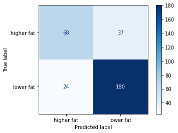

```python
# Display the confusion matrix.
plot_confusion_matrix(depth_search, X_test, y_test, values_format="d", cmap="Blues")
```

# Discussion

Once training is complete, it’s time to see if the model is any good. Using evaluation, this is where that dataset that we set aside earlier comes into play. Evaluation allows us to test our model against data that has never been used for training.

The final test score on the best model is **0.8025889967637541**.

This metric allows us to see how the model might perform against data that it has not yet seen. This is meant to be representative of how the model might perform in the real world.

According to Cross-validation, `RandomForestClassifier` model performs better than `DummyClassifier` model.

Besides, the `CountVectorizer()` transformer could be used in our pipeline with the `LogisticRegression` model for better outcomes by comparison with current models.

### Remarks

The power of machine learning is that we were able to determine how to differentiate between `higher fat` and `lower fat` using our model rather than using human judgement and manual rules. You can extrapolate the ideas presented today to other problem domains as well, where the same principles apply - gathering data, preparing that data, choosing a model, training it and evaluating it, doing your hyper parameter tuning, and finally, prediction. Thank you.